# Classification with K Nearest Neighbours (KNN)

For DATA50XX by ctong

## Overview

### What Is KNN?

K Nearest Neighbours (KNN) is a simple, intuitive machine learning method used for classification and regression. In classification, KNN predicts the category of a new observation based on the categories of its closest data points in the training set.

### How Does KNN Work?

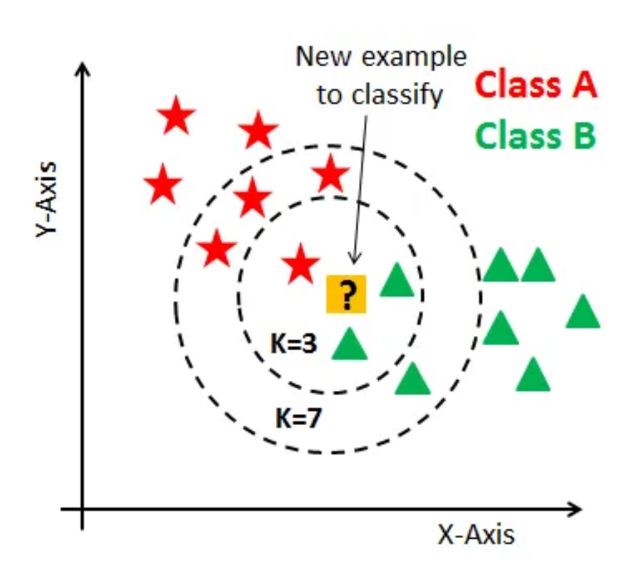

1. **Lazy Learning Algorithm**: No real learning. KNN does not build a model ahead of time. It stores the training data and defers computation until prediction is needed. It does not *learn* anything from the data in advance.
2. **Measure Distance**: To predict class for a new observation, KNN represents the feature values as a point in n-dimensional space and calculates the “distance” to every training point (commonly Euclidean distance).
3. **Find the K Nearest Neighbours**: It selects the **K closest** training points.
4. **Vote**: The most frequent class among these neighbours becomes the predicted class.

### Choosing the Right Value of K

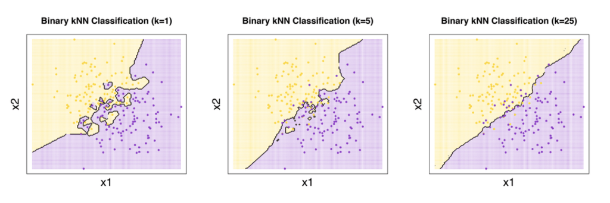

- Small K (e.g., 1) can be sensitive to noise.
- Large K smooths predictions but may overlook local patterns.
- Use cross-validation to choose K.

### Key Considerations

##### *Sensitivity to irrelevant features*

KNN treats all features equally. Irrelevant features can distort measures of similarity.

##### *Scale distortion*

Features must be on similar scales to avoid dominance by features on larger scales. **Solution:** Normalize (rescale to [0,1]) or Standardize (convert to z scores)

##### *Flexible decision boundaries*

- **Pro**: Captures complex patterns.
- **Con**: Can overfit if K is too small or data is noisy.

##### *Computationally expensive*

KNN does not train a model — it stores the data and compares new inputs to all training points when making predictions. This can be very slow and memory-heavy on large datasets.

##### *Curse of Dimensionality*

KNN may perform poorly with a large number of features. When there is a large number of dimensions, all points become far apart. The measure of distance becomes less meaningful, making it harder to find patterns. This is sometimes referred to as the *curse of dimensionality*. Proper feature selection is important before applying KNN for classification. KNN typically performs adequately with fewer than 10 features and it is generally recommended that the number of features be less than the square root of the number of observations in a data set to avoid overfitting.

## Demo

### Load Packages

```r
library(caret)
library(mlbench)
library(dplyr)
```

```r
library(ggplot2)
```

### Load and Prepare Data

We’ll use the `PimaIndiansDiabetes2` dataset, which contains medical information about patients and whether or not they have diabetes.

```r
data(PimaIndiansDiabetes2)
df <- na.omit(PimaIndiansDiabetes2)  # remove rows with missing values


# Inspect the data
str(df)
```

```
## 'data.frame':    392 obs. of  9 variables:
##  $ pregnant: num  1 0 3 2 1 5 0 1 1 3 ...
##  $ glucose : num  89 137 78 197 189 166 118 103 115 126 ...
##  $ pressure: num  66 40 50 70 60 72 84 30 70 88 ...
##  $ triceps : num  23 35 32 45 23 19 47 38 30 41 ...
##  $ insulin : num  94 168 88 543 846 175 230 83 96 235 ...
##  $ mass    : num  28.1 43.1 31 30.5 30.1 25.8 45.8 43.3 34.6 39.3 ...
##  $ pedigree: num  0.167 2.288 0.248 0.158 0.398 ...
##  $ age     : num  21 33 26 53 59 51 31 33 32 27 ...
##  $ diabetes: Factor w/ 2 levels "neg","pos": 1 2 2 2 2 2 2 1 2 1 ...
##  - attr(*, "na.action")= 'omit' Named int [1:376] 1 2 3 6 8 10 11 12 13 16 ...
##   ..- attr(*, "names")= chr [1:376] "1" "2" "3" "6" ...
```

### Cross-Validation with data preprocessing

```r
set.seed(123)
ctrl <- trainControl(method = "cv", number = 10)
knn_model <- train(diabetes ~ .,
                   data = df,
                   method = "knn",
                   trControl = ctrl,
                   preProcess = c("center", "scale"),
                   tuneLength = 20)

print(knn_model)
```

```
## k-Nearest Neighbors
##
## 392 samples
##   8 predictor
##   2 classes: 'neg', 'pos'
##
## Pre-processing: centered (8), scaled (8)
## Resampling: Cross-Validated (10 fold)
## Summary of sample sizes: 352, 353, 353, 353, 353, 353, ...
## Resampling results across tuning parameters:
##
##   k   Accuracy   Kappa
##    5  0.7627564  0.4376780
##    7  0.7601923  0.4227951
##    9  0.7575000  0.4072101
##   11  0.7651923  0.4336762
##   13  0.7394872  0.3565319
##   15  0.7521154  0.3859965
##   17  0.7573077  0.3981112
##   19  0.7574359  0.4029968
##   21  0.7573718  0.4027941
##   23  0.7598718  0.4069544
##   25  0.7700000  0.4322713
##   27  0.7648718  0.4146281
##   29  0.7674359  0.4260222
##   31  0.7675000  0.4222802
##   33  0.7751282  0.4347369
##   35  0.7776923  0.4392073
##   37  0.7700641  0.4188780
##   39  0.7802564  0.4438229
##   41  0.7674359  0.4115180
##   43  0.7700000  0.4192588
##
## Accuracy was used to select the optimal model using the largest value.
## The final value used for the model was k = 39.
```

- **Accuracy**: The proportion of correctly classified observations.
- **Kappa**: A measure of agreement between predicted and actual classes that adjusts for chance agreement.
- The best K value is listed in `knn_model$bestTune`.

### Visualizing performance for different Ks

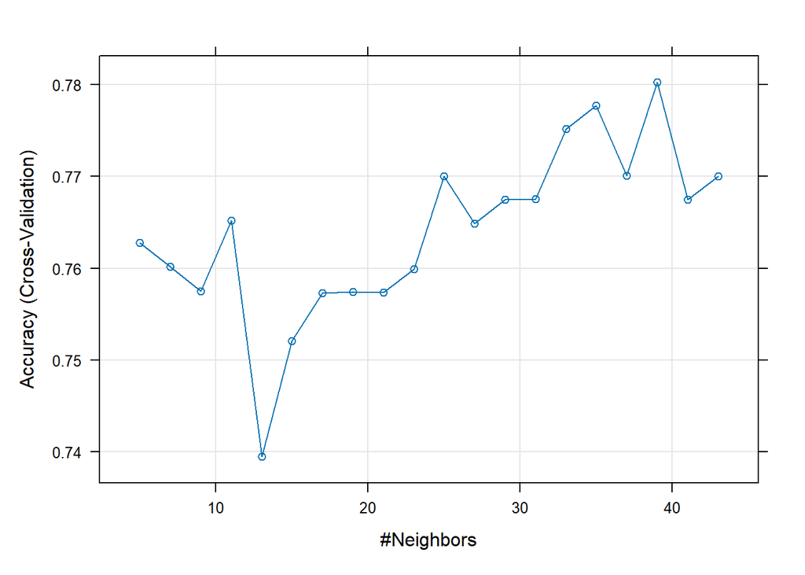

```r
plot(knn_model)
```

### Confusion Matrix

```r
pred <- predict(knn_model, newdata = df)
confusionMatrix(pred, df$diabetes)
```

```
## Confusion Matrix and Statistics
##
##           Reference
## Prediction neg pos
##        neg 242  67
##        pos  20  63
##
##                Accuracy : 0.7781
##                  95% CI : (0.7336, 0.8182)
##     No Information Rate : 0.6684
##     P-Value [Acc > NIR] : 1.229e-06
##
##                   Kappa : 0.4492
##
##  Mcnemar's Test P-Value : 8.151e-07
##
##             Sensitivity : 0.9237
##             Specificity : 0.4846
##          Pos Pred Value : 0.7832
##          Neg Pred Value : 0.7590
##              Prevalence : 0.6684
##          Detection Rate : 0.6173
##    Detection Prevalence : 0.7883
##       Balanced Accuracy : 0.7041
##
##        'Positive' Class : neg
##
```

- **Sensitivity**: Proportion of positives correctly identified (true positive rate).
- **Specificity**: Proportion of negatives correctly identified (true negative rate).
- **Balanced Accuracy**: Mean of sensitivity and specificity.